# Visualisierung der Entwicklung des realen BIP in der Schweiz

In diesem Notebook wird die Entwicklung des realen BIP in der Schweiz visualisiert. Die verwendeten Daten stammen vom Bundesamt für Statistik und vom SECO.

```python
import pandas as pd
```

```python
import matplotlib.pyplot as plt
import numpy as np
```

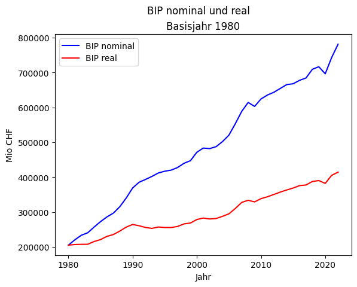

Das nominale BIP steigt stärker als das reale. Dies rührt dahrer, dass die Preise, wie sie im LIK abgebildet werden, im Beobachtungszeitraum gestiegen sind. Die Differenz zwischen den beiden Kurven ist damit der Inflation geschuldet.

Zwischen 2008 und 2021 scheinen die beiden Kurven allerdings weitgehend parallel zu verlaufen. Um dies zu prüfen, wird in einem nächsten Schritt das Referenzjahr auf das Jahr 2008 festgelegt.

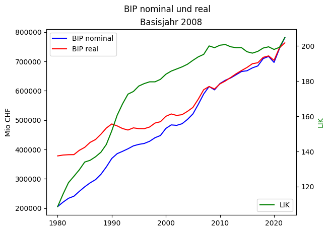

Die oben geäusserte Vermutung trifft zu. Zwischen 2008 und 2021 sind die Kurve des ralen und des nominalen BIP praktisch deckungsgleich. Dies wird durch die Entwicklung des LIK verdeutlicht. Wenn man grosszügig auf die Grafik schaut, entwickelt sich der LIK im fraglichen Zeitraum praktisch horizontal.

Um die Aussage noch deutlicher zu machen, wird als nächstes der LIK relativ zum Vorjahr dargestellt.

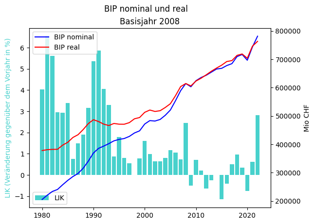

Die Darstellung der relativen Veränderung des LIK zeigt deutlich, dass ab 2008 eine Phase tiefer bis sogar netagiver Inflation beginnt. Ob dies andauert, kann aktuell noch nicht abschliessend beurteilt werden. Es mehren sich allerdings die Anzeichen, dass die Inflation wieder zurück ist.